# Berekeningen Inflatie | De Tijd

# Load libraries

```r
library(tidyverse)
library(readxl)
library(lubridate) #handling dates
library(DT) #html tables

#no scientific notation for numbers
options(scipen=999)
```

## CPI-data laden

```r
#Download cpi data (only enable when new download is needed)
#download.file(url='https://statbel.fgov.be/sites/default/files/files/opendata/Indexen%20per%20productgroep/CPI%20All%20groups.xlsx', destfile="data/cpi.xlsx")

#read cpi-data
df_cpi_og <- read_excel("data/cpi.xlsx", sheet = 1, col_types = "text")

#select relevant columns and clean variable names
df_cpi <- df_cpi_og %>%
  select(!contains(c("_FR_", "_EN_"))) %>%
  mutate(
    date = ymd(paste(NM_YR, NM_MTH, "1", sep="-")), #compose dates from year-month
    MS_CPI_IDX = as.numeric(gsub(",", ".", MS_CPI_IDX)), #reformat numbers
    MS_WT_CPI = as.numeric(gsub(",", ".", MS_WT_CPI)), #reformat weights
    CD_COICOP = gsub("\\.", "", CD_COICOP), #reformat coicop-codes
    NM_YR = as.numeric(NM_YR),
    NM_MTH = as.numeric(NM_MTH),
    MS_CPI_INFL = as.numeric(MS_CPI_INFL)*100
  )
```

## Inflatie reproduceren vanuit de publieke data

```r
#make subset with december months of each year
df_dec_months <- df_cpi %>%
  filter(NM_MTH == 12) %>%
  mutate(
    NM_YR = NM_YR + 1
  ) %>%
  select(CD_COICOP, NM_YR, IDX_DEC_Y_MINUS1 = MS_CPI_IDX)

#unchain
df_unchained <- df_cpi %>%
  select(CD_COICOP, date, NM_YR, NM_MTH, MS_CPI_IDX, MS_WT_CPI) %>%
  left_join(df_dec_months, by=c("NM_YR", "CD_COICOP")) %>%
  mutate(
    MS_CPI_IDX_ADJ = (MS_CPI_IDX / IDX_DEC_Y_MINUS1)*100
  )

#Vervolgens dien je deze unchained indices te aggregeren. Het bekomen resultaat kan gekoppeld worden aan de december index uitgedrukt in basis 2013=100. Op deze manier wordt de lange reeks van indexcijfers in basis 2013 = 100  bekomen.

#aggregate
df_agg_cpi_infl <- df_unchained %>%
  group_by(date, NM_YR, NM_MTH, CD_COICOP) %>%
  summarize(
    REPRODUCED_INDEX = weighted.mean(MS_CPI_IDX_ADJ, MS_WT_CPI) * (weighted.mean(IDX_DEC_Y_MINUS1, MS_WT_CPI) / 100)
  ) %>%
  ungroup() %>%
  group_by(CD_COICOP) %>%
  mutate(
    REPRODUCED_INFL = (REPRODUCED_INDEX / lag(REPRODUCED_INDEX, 12) - 1)*100
  )
```

[output not shown]

## Resultaat vergelijken met officieel gepubliceerde cijfers

Komt overeen met statbel https://statbel.fgov.be/nl/themas/consumptieprijsindex/consumptieprijsindex#figures

```r
## official inflation
official_indices <- df_cpi %>%
  filter(CD_COICOP == "-") %>%
  select(date, NM_MTH, NM_YR, OFFICIAL_IDX = MS_CPI_IDX, OFFICIAL_INFL = MS_CPI_INFL)

## compare with reproduced inflation
compare_infl <- df_agg_cpi_infl %>%
  filter(CD_COICOP == "-") %>%
  left_join(official_indices, c("date","NM_MTH", "NM_YR"))

#table to compare official inflation
compare_infl %>%
  select(date, OFFICIAL_INFL, REPRODUCED_INFL) %>%
  arrange(desc(date)) %>%
  datatable()
```

|  | CD_COICOP | date | OFFICIAL_INFL | REPRODUCED_INFL |
| --- | --- | --- | --- | --- |
| 1 | - | 2022-06-01 | 9.64959568733155 | 9.64959568733157 |
| 2 | - | 2022-05-01 | 8.96893291310221 | 8.96893291310219 |
| 3 | - | 2022-04-01 | 8.30627705627707 | 8.30627705627707 |
| 4 | - | 2022-03-01 | 8.30694054836665 | 8.30694054836667 |
| 5 | - | 2022-02-01 | 8.03919789492786 | 8.03919789492784 |
| 6 | - | 2022-01-01 | 7.59297990361008 | 7.59297990361005 |
| 7 | - | 2021-12-01 | 5.70828386153988 | 5.70828386153988 |
| 8 | - | 2021-11-01 | 5.63676228759364 | 5.63676228759367 |
| 9 | - | 2021-10-01 | 4.15906603429406 | 4.15906603429408 |
| 10 | - | 2021-09-01 | 2.86053737890697 | 2.86053737890697 |

[output cut: 284 more lines]

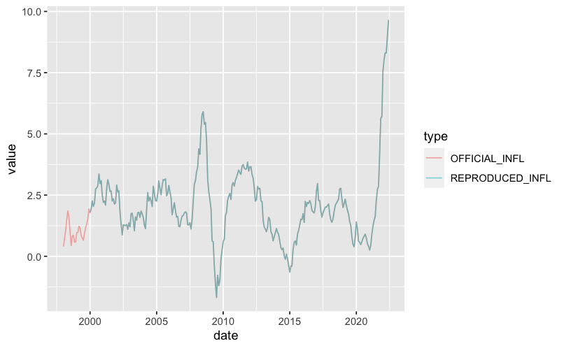

```r
#plot both
compare_infl %>%
  select(date, OFFICIAL_INFL, REPRODUCED_INFL) %>%
  gather(type, value, -c(date, CD_COICOP)) %>%
  ggplot(aes(x=date, y=value, col=type)) +
  geom_line(alpha=0.5)
```

# Herbereken inflatie via HBS

Vanaf hier proberen we de inflatie te herberekenen op basis van de HBS-data. Dat zou moeten toelaten om uitsplitsing te maken naar inkomensniveau

### HBS-data laden

```r
#Historische HBS-data binnenhalen
HBS_inc_2012 <- read_excel("data/HBO-2012-2014-2016.xls", sheet="HBS_Tab03_QRT_BE_2012", range="A5:Q1556")
```

[output not shown]

```r
HBS_inc_2014 <- read_excel("data/HBO-2012-2014-2016.xls", sheet="HBS_Tab03_QRT_BE_2014", range="A5:Q1556")
```

[output not shown]

```r
HBS_inc_2016 <- read_excel("data/HBO-2012-2014-2016.xls", sheet="HBS_Tab03_QRT_BE_2016", range="A5:Q1556")
```

[output not shown]

```r
HBS_inc_2018 <- read_excel("data/HBO-2018.xlsx", sheet="HBS_Tab03_QRT_BE_2018", range="A5:Q1556")
```

[output not shown]

```r
HBS_inc_2020 <- HBS_inc_2018

#Historische datasets bundelen
hbs_list_og <- list(
  "HBS_inc_2012"= HBS_inc_2012,
  "HBS_inc_2014"= HBS_inc_2014,
  "HBS_inc_2016"= HBS_inc_2016,
  "HBS_inc_2018"=HBS_inc_2018,
  "HBS_inc_2020"=HBS_inc_2020
  )

#datawrangling for all hbs dataframes in list
hbs_list <- lapply(seq_along(hbs_list_og), function(i){

  #remove first row and assign current dataframe to variable
  current_df <- hbs_list_og[[i]][-1, ]

  #rename columns
  names(current_df)[1:2] <- c("COICOP","desc")
  names(current_df)[3:5] <- paste("TOTAL-", names(current_df)[3:5])
  names(current_df)[6:8] <- paste("Q1-", names(current_df)[6:8])
  names(current_df)[9:11] <- paste("Q2-", names(current_df)[9:11])
  names(current_df)[12:14] <- paste("Q3-", names(current_df)[12:14])
  names(current_df)[15:17] <- paste("Q4-", names(current_df)[15:17])

  #gather data and clean variables
  current_df <- current_df %>%
    gather(category, value, -c(COICOP, desc)) %>%
    separate(category, c("category", "indicator"), sep="-") %>%
    mutate(
      indicator = gsub("\\(€\\)", "", indicator),
      indicator = gsub("\\.\\.\\.[0-9]+", "", indicator),
      indicator = gsub("Gemiddelde uitgaven per huishouden en per jaar", "mean_exp", indicator),
      indicator = gsub(" Aantal huishoudens \\(steekproef\\)", "n_households_sample", indicator),
      indicator = gsub(" Aantal huishoudens \\(bevolking\\)", "n_households_pop", indicator),
      indicator = trimws(indicator)
    )

  #add column name with year of hbs publication
  current_df$hbs_year <- as.numeric(gsub("HBS_inc_","",names(hbs_list_og)[i]))

  return(current_df)

}) #end of loop

#merge all historic hbs-dataframes in one single dataframe
df_hbs <- hbs_list %>%
  bind_rows() %>%
  mutate(
    value = gsub("-", NA, value), #convert blank values to NA
    value = as.numeric(value)
  ) %>%
  filter(indicator == "mean_exp") %>% #only variable of interest is the mean expenditure
  filter(!is.na(desc)) %>% #remove empty rows and metadata
  mutate(COICOP_LVL = nchar(COICOP) - 1) #add variable to identify coicop-level
```

## Herschaal HBS-gewichten volgens inkomensgroep

### Specifieke producten definiëren

```r
#list of hbs-categories included by nbb as found on:
#https://www.nbb.be/doc/ts/publications/economicreview/2020/ecoreviii2020_h6.pdf (footnote 2 on page 11)
include_selection <- read.csv("data/nbb-level2-products.csv", sep=";", stringsAsFactors = F, colClasses="character")

#additional products to be removed from subset
exclude_selection <- c(
    "023", # drugs,
    "122", #prostitution
    "1251", #life insurance
    "12530B", # hospital insurances
    "12530C" # health insurance
  )

#create searchquery for all product codes that are INCLUDED by nbb (AND ALL CHILD ELEMENTS!)
include_query <-  paste0("^(", paste(include_selection$COICOP, collapse = "|"), ")")

#create searchquery for all product codes that are REMOVED by nbb (AND ALL CHILD ELEMENTS!)
exclude_query <- paste0("^(", paste(exclude_selection, collapse = "|"), ")")

paste("include all product codes starting with:", include_query)
```

```
[1] "include all product codes starting with: ^(01|02|03|041|043|044|0451|0452|0453|0454|05|06|071|0721|07221|07222|07223|07224|0723|0724|073|08|09|10|11|12)"
```

```r
paste("exclude all product codes starting with:", exclude_query)
```

```
[1] "exclude all product codes starting with: ^(023|122|1251|12530B|12530C)"
```

### Specifieke producten wegfilteren / binnenladen

```r
# include/exclude selection toepassen op hbs data
filtered_hbs <- df_hbs %>%
  filter(str_detect(COICOP, include_query)) %>% #apply INCLUDE query
  filter(!str_detect(COICOP, exclude_query)) %>%  #apply EXCLUDE query
  filter(COICOP_LVL == 5) # Enkel producten op het diepste niveau

#summarize filtered hbs to coicop level 4
recalc_hbs <- filtered_hbs  %>%
  mutate(
    `4` = substr(COICOP, 1,5),
    `3` = substr(COICOP, 1,4),
    `2` = substr(COICOP, 1,3),
    `1` = substr(COICOP, 1,2),
    `0` = "-"
  ) %>%
  gather("coicop_parent_lvl", "coicop_parent", -c(COICOP:COICOP_LVL)) %>%
  group_by(coicop_parent, category, hbs_year) %>%
  summarize(value = sum(value, na.rm=T)) %>%
  filter(coicop_parent %in% include_selection$COICOP)
```

[output not shown]

```r
# Totale uitgaven per inkomensgroep
recalc_group_expenditure <- filtered_hbs %>%
  group_by(category, hbs_year) %>%
  summarize(recalc_total_group_expenditure = sum(value, na.rm=T))
#calculate relative weights from each product group in relation to total expenditure by income group
new_relative_hbs_weights <- recalc_hbs %>%
  left_join(recalc_group_expenditure, by=c("category", "hbs_year")) %>%
  rename("CD_COICOP" = "coicop_parent") %>%
  group_by(CD_COICOP,category, hbs_year ) %>%
    summarize(
    wt_rescaled_inc_group = (value / recalc_total_group_expenditure)*1000
  )
```

[output not shown]

## Price Update

### Vermenigvuldigingsfactor voor price update

- Om tot het wegingsschema 2018 te komen worden de uitgaven van de gezinnen in 2016 geactualiseerd naar december 2017. Dat gebeurt door de gewichten op het meest gedetailleerde gepubliceerde niveau te vermenigvuldigen met de gemeten prijsevolutie tussen december 2017 en het jaar 2016 (dit is de verhouding van de index in december 2017 ten opzichte van de gemiddelde index van 2016).
- Voor productgroepen met sterke seizoenschommelingen worden de jaargemiddelde indexen van 2016 en 2017 gebruikt voor de price update.

Voorbeeld: Weight in 2018 = hbs-wt van 2016 * (index van december 2017 / gemiddelde index van 2016)

Voorbeeld: Weight in 2021 = hbs-wt van 2018 * (index van december 2020 / gemiddelde index van 2018)

Nationale bank doet precies iets anders:

JJ (NBB): "Heb het even opgezocht op de website van Statbel: de formule is correct. Ik heb het iets anders gedaan (wij streven enkel een benadering na):

Gewicht van getuige in HBS 2016 * [ (Index per getuige in december 2017 / Index per getuige in december 2016) / (Totale index in december 2017 / Totale index in december 2016) ]

“Ik deel door de totale index om een totaal gewicht van 1000 te bekomen.”

–> Reproductie van totale inflatie is gelukt MAAR uitsplitsing naar inkomensgroep kon niet worden gedaan op basis van de beschikbare informatie. Dat komt omdat Jonckheere hier gebruik maakt van een eigen index voor gas en elektriciteit als vertrekpunt. Ze zegt daarover:

"Ongeveer 80 % (= ruwe schatting) van het laagste inkomenskwartiel heeft recht op het sociaal tarief, en de tarieven daarvan zijn veel minder gestegen dan de commerciële tarieven. Die groep tekent dus een lagere inflatie op (zie sheet “Q25 _sociaal tarief”). Hiervoor heb ik mijn index voor elektriciteit en gas (sociaal tarief) zélf berekend, op basis van tarieven van sociaal tarief gepubliceerd door de CREG. De overige 20 % van het laagste inkomenskwartiel betaalt het commercieel tarief, dus die groep is het hardst getroffen door inflatie. Dus, in alle sheets, behalve “totaal” en “Q25_sociaal tarief” gebruik ik dan ook mijn eigen berekende index voor het pure commercieel tarief (dit op basis van de totale gepubliceerde index en mijn index voor sociaal tarief). Alleen in de sheet “totaal” (waar ik de totale inflatie reproduceer, en ik mijn resultaat vergelijk met dat van statbel) gebruik ik de officiële totale index voor gas en elektriciteit (wat een gewogen gemiddelde is van de commerciële index en de index met sociaal tarief)."

# Inflatiebrekening per inkomensgroep

```r
#make empty list
testlist <- list()

category <- c("Q1", "Q2", "Q3", "Q4", "TOTAL")
base_index <- c(100, 100, 100, 100, 100)
df_startindex <- data.frame(category, base_index)

#basic variables
testlist[["2017"]][["new_index_dec_y-1"]] <- df_startindex

testlist[["2017"]][["cpi"]] <- df_cpi %>%
  filter(CD_COICOP %in% include_selection$COICOP) %>%
  filter(NM_YR == 2017) %>%
  select(CD_COICOP, date, MS_CPI_IDX, NM_YR)

testlist[["2017"]][["dec_cpi"]] <- df_cpi %>%
  filter(NM_YR == 2017) %>%
  filter(NM_MTH == 12) %>%
  rename("year_dec_value"="NM_YR") %>%
  mutate(
    year_to_update = year_dec_value  + 1
  ) %>%
  select(year_dec_value, year_to_update, CD_COICOP, cpi_idx_dec = MS_CPI_IDX) %>%
  filter(CD_COICOP != "-")

# VARIABLES FOR STARTYEAR

#STEP 1: GET CPI PER PRODUCT
testlist[["2018"]][["cpi"]] <- df_cpi %>%
filter(NM_YR == 2018) %>%
filter(CD_COICOP %in% include_selection$COICOP) %>%
  select(CD_COICOP, date, MS_CPI_IDX, NM_YR)

#STEP 2: GET WEIGHTS
testlist[["2018"]][["weights"]] <- new_relative_hbs_weights %>%
  filter(hbs_year == 2018)

#STEP 3: Evolutiescore tegenover december_year_minus_one
testlist[["2018"]][["cpi_evo"]] <- testlist[["2018"]][["cpi"]] %>%
  left_join(testlist[["2017"]][["dec_cpi"]], by=c("NM_YR" = "year_to_update", "CD_COICOP")) %>%
  group_by(CD_COICOP) %>%
  mutate(
    factor = MS_CPI_IDX / cpi_idx_dec
  )

#STEP 4: Gewogen gemiddelde per datum volgens coicop-gewichten
testlist[["2018"]][["weighted_means"]] <- testlist[["2018"]][["cpi_evo"]] %>%
  left_join(testlist[["2018"]][["weights"]], by=c("NM_YR" = "hbs_year", "CD_COICOP")) %>%
  group_by(category, date) %>%
  summarize(weighted_factor = weighted.mean(factor,wt_rescaled_inc_group)) %>%
  ungroup() %>%
  filter(!is.na(category))
View(testlist[["2018"]][["weighted_means"]])

#STEP 5: nieuwe cpi-index berekenen
testlist[["2018"]][["new_index"]] <- testlist[["2018"]][["weighted_means"]] %>%
  left_join(testlist[["2017"]][["new_index_dec_y-1"]], by=c("category")) %>%
  mutate(
    new_index = base_index*weighted_factor
    )

# VARIABLES FOR EACH CONSECUTIVE YEAR

for(curr_year in c(2019, 2020, 2021, 2022)){

  ## STEP 1: GET CPI PER PRODUCT
  testlist[[paste(curr_year)]][["cpi"]] <- df_cpi %>%
  filter(NM_YR == curr_year) %>%
  filter(CD_COICOP %in% include_selection$COICOP) %>%
    select(CD_COICOP, date, MS_CPI_IDX, NM_YR)

  ## STEP 2: UPDATE WEIGHTS

  ### coicop cpi-index of dec y-1
  coicop_cpi_dec_y_minus1 <- testlist[[paste(curr_year - 1)]][["cpi"]] %>%
    filter(month(date) == 12) %>%
    mutate(year = year(date)) %>%
    select(CD_COICOP, coicop_cpi_dec_y_minus1 = MS_CPI_IDX, year)

  ### avg coicop-cpi-index of 2018
  avg_coicop_cpi_y_minus1 <- testlist[["2018"]][["cpi"]] %>%
    group_by(CD_COICOP) %>%
    summarize(avg_coicop_cpi_y_minus1 = mean(MS_CPI_IDX, na.rm=T))

  ### new idx of dec y-1
  new_idx_dec_y_minus1 <- testlist[[paste(curr_year - 1)]][["new_index"]] %>%
    filter(month(date) == 12) %>%
    mutate(year = year(date)) %>%
    select(category, year, new_idx_dec_y_minus1 = new_index)

  ### avg new idx of 2018
  avg_new_idx_y_minus1 <- testlist[["2018"]][["new_index"]] %>%
    group_by(category) %>%
    summarize(avg_new_idx_y_minus1 = mean(new_index, na.rm=T))

  ### calculate update factors
  update_factors <- coicop_cpi_dec_y_minus1 %>%
    left_join(avg_coicop_cpi_y_minus1, c("CD_COICOP")) %>%
    left_join(new_idx_dec_y_minus1, "year") %>%
    left_join(avg_new_idx_y_minus1, c("category")) %>%
    select(CD_COICOP, year, category, everything()) %>%
    ungroup() %>%
    group_by(category, CD_COICOP) %>%
    summarize(
      update_factor = (coicop_cpi_dec_y_minus1 / avg_coicop_cpi_y_minus1) / (new_idx_dec_y_minus1 / avg_new_idx_y_minus1),
      year = curr_year + 1
    )

  ### apply update factors
  testlist[[paste(curr_year)]][["weights"]] <- testlist[["2018"]][["weights"]] %>%
    left_join(update_factors, by=c("CD_COICOP", "category")) %>%
    mutate(
      new_weight = wt_rescaled_inc_group*update_factor
    ) %>%
    select(CD_COICOP, category, new_weight)


  #STEP 3: Evolutiescore tegenover december_year_minus_one
  testlist[[paste(curr_year) ]][["cpi_evo"]] <- testlist[[paste(curr_year)]][["cpi"]] %>%
    left_join(coicop_cpi_dec_y_minus1 %>% mutate(year_to_update = year + 1), by=c("NM_YR" = "year_to_update", "CD_COICOP")) %>%
    group_by(CD_COICOP) %>%
    mutate(
      factor = MS_CPI_IDX / coicop_cpi_dec_y_minus1
    ) %>%
    select(CD_COICOP, date, factor)

  #STEP 4: Gewogen gemiddelde per datum volgens coicop-gewichten
  testlist[[paste(curr_year)]][["weighted_means"]] <- testlist[[paste(curr_year)]][["cpi_evo"]] %>%
    left_join(testlist[[paste(curr_year)]][["weights"]], by=c("CD_COICOP")) %>%
    group_by(category, date) %>%
    summarize(weighted_factor = weighted.mean(factor, new_weight)) %>%
    ungroup() %>%
    filter(!is.na(category))

  #STEP 5: nieuwe cpi-index berekenen
  testlist[[paste(curr_year)]][["new_index"]] <- testlist[[paste(curr_year)]][["weighted_means"]] %>%
    left_join(
      testlist[[paste(curr_year - 1)]][["new_index"]] %>%
        filter(month(date) == 12) %>%
        select(category, base_index = new_index),
      by=c("category")
      ) %>%
    mutate(
      new_index = base_index*weighted_factor
      )

  #STEP 6: calculate inflation
  testlist[[paste(curr_year)]][["inflation"]] <- testlist[[paste(curr_year - 1)]][["new_index"]] %>%
    bind_rows(testlist[[paste(curr_year)]][["new_index"]]) %>%
    group_by(category) %>%
  mutate(
    inflation = (new_index / lag(new_index, 12) - 1)*100
  ) %>%
    filter(year(date) == curr_year)

} #end of loop
```